# R Example 1

Renee Wu

### Part I. Data cleaning

#### 1) Library and directory set up

```r
# clean ----------------------------------------------------------
rm(list=ls())
graphics.off()

# library ---------------------------------------------------------
library(readxl)
## Import excel files into R.
library(here)
library(Hmisc)
library(tidyverse)
## Includes the packages that you’re likely to use in everyday data analyses: ggplot2, dplyr, tidyr, readr ...)
library(janitor)
## to use tabyl function
library(flextable)
## provides a framework for easily create tables for reporting and publications.
library(officer)
## manipulate images, tables and text into documents from R.
library(lme4)
## Fit linear and generalized linear mixed-effects models.
library(mice)
## Multivariate Imputation by Chained Equations.
library(rms)
library(ggpubr)
##'ggplot2' Based Publication Ready Plots, use comparemeans to add p-values a lot.
library(mosaic)
#library(tableone)
library(compareGroups)
library(REDCapTidieR)

# set output format of word document ----------------------------------------------
set_flextable_defaults(font.size = 9, theme_fun = theme_vanilla, padding = 6, font.family = "Times New Roman")

# work directory --------------------------------------------------
BaseDir <- here::here()
OrigDataDir <- paste(BaseDir, "/orig_data/", sep = "")
DataDir <- paste(BaseDir, "/data/", sep = "")
GraphDir <- paste(BaseDir, "/graphs/", sep = "")
OtherDir <- paste(BaseDir, "/others/", sep = "")
```

#### 2) Load data via REDCap API

Because investigators edited columns directly in Excel, the resulting column names were not programming-friendly. To retain the most updated datasets and variable labels, Excel files were loaded as-is. Meanwhile, REDCap projects were connected via API to standardize column names into a format that is more suitable for programming.

```r
#load excel files
og.tofa <- read_excel(paste0(OrigDataDir, "Tofa Extract v2.0.xlsx")) %>% unique()
og.upa <- read_csv(paste0(OrigDataDir, "Upadacitinib extract v2.0.csv")) %>% unique()

#read REDCap token and URI
#do NOT directly type REDCap API token in the programming scripts to ensure data security
token.tofa <- read_excel(paste0(OrigDataDir, "redcap_token.xlsx"), sheet = "Tofa") %>% select(token) %>% unlist()
token.upa <- read_excel(paste0(OrigDataDir, "redcap_token.xlsx"), sheet = "Upa") %>% select(token) %>% unlist()
ccfuri <- read_excel(paste0(OrigDataDir, "redcap_token.xlsx"), sheet = "Upa") %>% select(redcap_uri) %>% unlist()

ogrc.tofa <- read_redcap(redcap_uri = ccfuri, token = token.tofa)
ogrc.upa <- read_redcap(redcap_uri = ccfuri, token = token.upa)
```

#### 3) Update column names with REDCap dataset to excel file

```r
#obtain original variable and labels------
ogrc.tofa.lab <- tidyr::unnest(ogrc.tofa, cols = redcap_metadata) %>%
  select(field_name, field_label) %>% unique() %>%
  mutate(field_label = str_to_sentence(field_label))

ogrc.upa.lab <- tidyr::unnest(ogrc.upa, cols = redcap_metadata) %>%
  select(field_name, field_label) %>% unique() %>%
  mutate(field_label = str_to_sentence(field_label))

#tofa --------------------------------------------------
#tidy tofa labels
tofa.lab.all <- names(og.tofa) %>% as.data.frame() %>% setNames("tofa_label") %>%
  mutate(tofa_label = str_to_sentence(tofa_label)) %>%
  mutate(tofa_label = str_squish(tofa_label)) %>%
  mutate(
    # Extract the choice value
    choice_value = str_extract(tofa_label, "(?<=\\(choice=)[^)]+"),
    # Remove the entire (choice=...) part
    tofa_label = str_remove(tofa_label, "\\s*\\(choice=[^)]+\\)"),
    # Append the choice value (if it exists)
    tofa_label = if_else(!is.na(choice_value), paste0(tofa_label,": ", choice_value), tofa_label)
  ) %>%
  select(-choice_value) %>%
  left_join(ogrc.tofa.lab, join_by(tofa_label == field_label)) %>%
  mutate(field_name = case_when(tofa_label == "Redcap id" ~ "redcap_id",
                                tofa_label == "Age at tofacitinib initiation" ~ "age_at_tofa_initiation",
                                tofa_label =="Date of starting tofacitinib" ~ "tofa_start_date",
                                tofa_label == "Tofa to colectomy in days" ~ "tofa_to_surg_days",
                                grepl("dose",tofa_label, ignore.case = TRUE) ~ "tofa_maint_dose",
                                TRUE ~ field_name)) %>%
  mutate(field_name = str_replace(field_name, "tofa", "jaki")) %>%
  mutate(field_name = str_replace(field_name, "toda", "jaki"))

#upad -------------------------------------------------------
#tidy tofa labels
upa.lab.all <- names(og.upa) %>% as.data.frame() %>% setNames("upa_label") %>%
  mutate(upa_label = str_to_sentence(upa_label)) %>%
  mutate(upa_label = str_squish(upa_label)) %>%
  mutate(
    # Extract the choice value
    choice_value = str_match(upa_label, "\\(choice=(.*)\\)")[,2],
    # Remove the entire (choice=...) part
    upa_label = str_remove(upa_label, "\\s*\\(choice=.*\\)$"),
    # Append the choice value (if it exists)
    upa_label = if_else(!is.na(choice_value), paste0(upa_label, ": ", choice_value), upa_label)
  ) %>%
  select(-choice_value) %>%
  left_join(ogrc.upa.lab, join_by(upa_label == field_label)) %>%
  mutate(field_name = case_when(upa_label == "Redcap id" ~ "redcap_id",
                                upa_label == "Days difference between upa and colectomy" ~ "upa_to_surg_days",
                                upa_label == "Date of starting upadacitinib" ~ "upa_start_date",
                                upa_label == "Composit end point steroid-free remission" ~ "composite_remission",
                                upa_label == "Upa maintenance dose" ~ "upa_maint_dose",
                                upa_label == "Age at upadacitinib initiation" ~ "age_at_jaki_initiation",
                                field_name == "tofa_discont_reason" ~ "upa_discont_reason",
                                ###update upa labels to match tofa lables:
                                field_name == "vte_prior" ~ "vte",
                                field_name == "vte_after" ~ "vte_2",
                                field_name == "endoscopic_remission_2" ~ "endoscopic_resp",
                                TRUE ~ field_name)) %>%
  mutate(field_name = str_replace(field_name, "upa", "jaki"))

#update og.upa and og.tofa to variable name
names(og.tofa) <- tofa.lab.all$field_name
names(og.upa) <- upa.lab.all$field_name
```

#### 4) Create project data table

Extract variables from each drug dataset, then merge the two datasets.

```r
#select variable of interests for the project -----
#tofa -----------
tofa.proj <- og.tofa %>%
  transmute(proj_id = paste0("tofa", redcap_id),
            age_at_jaki_initiation, disease_duration, followup_duration,patient_gender, patient_race, dx_smoking, vte, family_hx, disease_location, hospitalizations, hosp_post_therapy, extraintestinal_manifest___1, extraintestinal_manifest___2, extraintestinal_manifest___3, extraintestinal_manifest___4, extraintestinal_manifest___5, extraintestinal_manifest___6, other_immune_conditions___1, other_immune_conditions___2, other_immune_conditions___3, other_immune_conditions___4, other_immune_conditions___5, other_immune_conditions___6, other_immune_conditions___7, other_immune_conditions___8, hx_of_malig___1,hx_of_malig___2,hx_of_malig___3,hx_of_malig___4,
            crp_at_diagnosis, crp_at_three_months, crp_at_sixtonine, crp_at_twelvetoeighteen, calprotectin_dx, calprotectin_three, calprotectin_six_to_nine, calprotectin_12_18,
            biochem_resp, biochem_remission,
            mayoscore_before_dx, mayoscore_3months,mayoscore_6to9months, mayoscore_12_18months,
            endoscopic_resp, endoscopic_remission, charleson_score, previous_biologics___1,previous_biologics___2,previous_biologics___3,previous_biologics___4,previous_biologics___5,previous_biologics___6,previous_biologics___7,previous_biologics___8,previous_biologics___9,previous_biologics___10, steriod_at_dx, asa_at_dx, immunosup_dx___1, immunosup_dx___2, composite_remission, jaki_maint_dose,
            surg_date, jaki_to_surg_days,
            hx_of_severe_infection, hx_of_non_severe_infection, hx_of_malig_2___2, hx_of_malig_2___3, vte_2, death_cause, death_age) %>%
  dplyr::rename(other_immune_none = other_immune_conditions___8) %>%
  mutate(surg_date = as.character(surg_date))

#upa ----------
upa.proj <- og.upa %>%
  transmute(proj_id = paste0("upa", redcap_id), age_at_jaki_initiation, disease_duration, followup_duration, patient_gender, patient_race, dx_smoking, vte, family_hx, disease_location, hospitalizations, hosp_post_therapy, extraintestinal_manifest___1,extraintestinal_manifest___2,extraintestinal_manifest___3,extraintestinal_manifest___4,extraintestinal_manifest___5,extraintestinal_manifest___6, other_immune_conditions___1,other_immune_conditions___2,other_immune_conditions___3,other_immune_conditions___4,other_immune_conditions___5,other_immune_conditions___6, other_immune_conditions___7, other_immune_conditions___10, hx_of_malig___1,hx_of_malig___2,hx_of_malig___3,hx_of_malig___4,
            crp_at_diagnosis, crp_at_three_months, crp_at_sixtonine, crp_at_twelvetoeighteen, calprotectin_dx, calprotectin_three, calprotectin_six_to_nine, calprotectin_12_18,
            biochem_resp, biochem_remission,
            mayoscore_before_dx,mayoscore_3months, mayoscore_6to9months, mayoscore_12_18months,
            endoscopic_resp, endoscopic_remission, charleson_score, previous_biologics___1,previous_biologics___2,previous_biologics___3,previous_biologics___4,previous_biologics___5,previous_biologics___6,previous_biologics___7,previous_biologics___8, previous_biologics___9, previous_biologics___10, steriod_at_dx, asa_at_dx, immunosup_dx___1, immunosup_dx___2, composite_remission, jaki_maint_dose,
            surg_date, jaki_to_surg_days,
            hx_of_severe_infection, hx_of_non_severe_infection, hx_of_malig_2___2, hx_of_malig_2___3, vte_2, death_cause, death_age) %>%
  dplyr::rename(other_immune_none = other_immune_conditions___10)

summary(tofa.proj)
summary(upa.proj)

Hmisc::describe(tofa.proj)
Hmisc::describe(upa.proj)
```

Check if column names are consistent between two datasets before combining:

```r
#check column names consistency before combining
setdiff(names(upa.proj), names(tofa.proj)) #0
setdiff(names(tofa.proj), names(upa.proj)) #0

#combine data sets for each drug into one
dat <- bind_rows(tofa.proj, upa.proj)
```

#### 5) Update labels

```r
varlab_proj <- names(dat) %>% as.data.frame() %>% setNames("var_name") %>%
  left_join(ogrc.tofa.lab, join_by("var_name" == "field_name")) %>%
  mutate(field_label = case_when(var_name == "proj_id" ~ "ID",
                              var_name == "age_at_jaki_initiation" ~ "Age at jaki initiation",
                              var_name =="other_immune_none" ~ "Other immune related conditions: none",
                              var_name == "jaki_maint_dose" ~ "maintenance dosage",
                              var_name == "jaki_to_surg_days" ~ "JAKi to colectomy in days",
                              TRUE ~ field_label)) %>%
  mutate(field_label = field_label %>%
                         str_replace_all(regex("tofa(citinib)?", ignore_case = TRUE), "jaki") %>%
                         str_remove("/xeljanz") %>%
                         str_squish()) %>%
  deframe()

dat <- set_variable_labels(dat, !!!varlab_proj)
```

Alternative way to set variable labels: `set_variable_labels(dat, .labels = varlab_proj)`. This is used if `varlab_proj` is already in the correct format (i.e. each element is unpacked: proj_ID = “ID”)

However, here, variable label list `varlab_proj` is not unpacked. Therefore, use triple-bang `!!!` to unpack it.

Then check if variable label list is successfully unpacked and applied:

```r
purrr::walk2(names(varlab_proj), varlab_proj, ~cat(.x, "=", .y, "\n"))

summary(dat)
Hmisc::describe(dat)
```

#### 5) Derive new variables for analysis

```r
#update dat with new columns
dat.tidy <- dat %>%
  mutate(jaki_type = ifelse(grepl("tofa", proj_id), "Tofacitinib", "Upadacitinib"),
         age_group = ifelse(age_at_jaki_initiation<50,"<50", ">=50"),
         caucasian = ifelse(patient_race == "White/Caucasian", "Yes", "No"),
         male = ifelse(patient_gender == "Male", "Yes", "No"),
         disease_location_2 = case_when(grepl("Left Sided", disease_location) ~ "Left sided",
                                        grepl("Pancolitis", disease_location) ~ "Pancolitis",
                                        grepl("proctitis", disease_location) ~ "Procititis"),
         extraintestinal_manifest_totcount = rowSums(across(extraintestinal_manifest___1:extraintestinal_manifest___5, ~ .x == "Yes"), na.rm = TRUE),
         other_immune_conditions_totcount = rowSums(across(other_immune_conditions___1:other_immune_conditions___7, ~ .x == "Yes"), na.rm = TRUE),
         prior_biologics_count = rowSums(across(previous_biologics___1:previous_biologics___9, ~ .x == "Yes"), na.rm = TRUE),
         prior_biologics_group = factor(
           case_when(prior_biologics_count ==0 ~ "0",
                     prior_biologics_count ==1 ~ "1",
                     prior_biologics_count >=2 ~ ">=2"),
           levels = c("0", "1", ">=2")),
         colectomy = ifelse(!is.na(surg_date), "Yes", "No"),
         death_allcause = ifelse(!is.na(death_cause), "Yes", "No"),
         death_jaki = ifelse(grepl("jaki", death_cause), "Yes", "No"),
         dosage_group = case_when(jaki_type == "Tofacitinib" & jaki_maint_dose == 10 ~ "Tofa high doses",
                                  jaki_type == "Tofacitinib" & jaki_maint_dose == 5 ~ "Tofa low doses",
                                  jaki_type == "Upadacitinib" & (jaki_maint_dose == 30 | jaki_maint_dose == 15) ~ "Upa low doses",
                                  jaki_type == "Upadacitinib" & jaki_maint_dose == 45 ~ "Upa high doses")
         ) %>%
  set_variable_labels(jaki_type = "Patient JAKi type",
                      age_group = "Age group",
                      caucasian = "Caucasians",
                      male = "Male",
                      disease_location_2 = "Disease location",
                      extraintestinal_manifest_totcount = "Number of extraintestinal manifestation",
                      other_immune_conditions_totcount = "Number of immune-related conditions",
                      prior_biologics_count = "Total number of previous biologics",
                      prior_biologics_group = "Previous biologics",
                      colectomy = "Colectomy surgery",
                      death_allcause = "All-cause mortality",
                      death_jaki = "Death related to JAKi",
                      dosage_group = "JAKi maintenance dosage group")


summary(dat.tidy)
Hmisc::describe(dat.tidy)
```

#### 6) Export data and create data dictionary

```r
#create R data for record keeping
#save(dat.tidy, file=paste0(DataDir, "proj_dat_tidy_", Sys.Date(), ".Rdata"))

#create data dictionary
ref <- var_label(dat.tidy) %>%
  unlist() %>%
  enframe(name = "variable", value = "label")
#writexl::write_xlsx(ref, paste0(DataDir, "proj_dat_codebook.xlsx"))
```

### Part II. Analysis

#### 1) Table 1

Univariate analysis for major parameters of interests of the study. Need to test normality for continuous variables in order to apply the right test.

```r
dat.tbl1 <- dat.tidy %>%
  select(jaki_type, age_group, disease_duration, followup_duration, male, caucasian, dx_smoking, vte, family_hx, disease_location_2, hospitalizations, hosp_post_therapy, extraintestinal_manifest___1:extraintestinal_manifest___6, extraintestinal_manifest_totcount, other_immune_conditions___1:other_immune_none, other_immune_conditions_totcount, hx_of_malig___1:hx_of_malig___4, crp_at_diagnosis, calprotectin_dx, mayoscore_before_dx, charleson_score, prior_biologics_group, steriod_at_dx, asa_at_dx, immunosup_dx___1, immunosup_dx___2)

#test normality
numeric_vars <- dat.tbl1 %>% select(where(is.numeric)) %>% names()
normality_results <- numeric_vars %>%
  map_df(~ {
    pval <- tryCatch(
      shapiro.test(dat.tbl1[[.x]])$p.value,
      error = function(e) NA
    )
    tibble(variable = .x, p.value = pval)
  })

#update methods for continuous variables
method_list <- normality_results %>%
  mutate(method = if_else(p.value > 0.05, "continuous", "nonparametric")) %>%
  deframe()
```

Generate table, then use `flextable` to make it publication ready:

```r
table1 <- descrTable(age_group~., data = dat.tbl1, method = method_list, show.all = T,
                   show.p.overall = T,extra.labels = c("","",""), show.n = T,
                   include.miss = F, hide.no = "No")

#present table using flextable to be publication ready:
tbl1 <- table1$descr %>%
  as.data.frame () %>%
  tibble::add_column(Variable3 = rownames(.)) %>% #turn the rownames into an actual column
  as_tibble() %>% #change to tibble bc it is more informative
  dplyr::select(Variable3, everything()) %>% #rearrange the variables
  separate(Variable3, c("Variable3", "Level"), ":") %>% #separate on the :
  mutate(Variable2 = case_when(Variable3 == lag(Variable3) ~ "Remove",
                               Variable3 != lag(Variable3) ~ Variable3)) %>%
  mutate(Variable = case_when(is.na(Variable2) == T ~ Variable3,
                              Variable2 == Variable3 ~ Variable3,
                              Variable2 == "Remove" ~ "")) %>%
  mutate(pnew = ifelse(p.overall == "<0.001", 0.0001,as.numeric(p.overall)),
  ## define publishable p-value format
         pnewfmt = case_when(pnew < 0.001 ~"<0.001",
                              pnew >= 0.001 & pnew < 0.095 ~
                                paste0(sprintf("%.3f", round(pnew,3))), ## keep ending 0
                              pnew  >= 0.095 & pnew <= 0.99 ~
                                paste0(sprintf("%.2f", round(pnew,2))),
                             pnew > 0.99 ~ ">0.99")) %>%
  dplyr::select(Variable,everything()) %>%
  dplyr::select(-c(Variable2,Variable3,p.overall,pnew)) %>%
  relocate(pnewfmt, .before = N) %>%
  dplyr::rename(
         !!paste("All (n=",max(as.numeric(table1$avail[,1]), na.rm = TRUE),")", sep = "") := 3,
         !!paste(colnames(table1$avail)[2]," (n=",max(as.numeric(table1$avail[,2]), na.rm = TRUE),")",sep = "") := 4,
         !!paste(colnames(table1$avail)[3]," (n=",max(as.numeric(table1$avail[,3]), na.rm = TRUE),")",sep = "") := 5,
         # !!paste(colnames(table2$avail)[4]," (n=",max(as.numeric(table2$avail[,4]), na.rm = TRUE),")",sep = "") := 6
         "P-value" = 6,
         "N" = 7
        ) %>%
  flextable(.) %>%
  autofit(.) %>%
  add_header_row(., top = TRUE, values = "Table 1. Patient Characteristics", colwidths = 7) %>%
  add_footer_lines(., "Non-normally distributed continuous variables presented as Median (IQR). Categorical variables presented as N (column %).") %>%
  bold(i = ~ `P-value` == "<0.001" | as.numeric(`P-value`) <= 0.05, j = "P-value", bold = TRUE) %>%
  bold(., bold = TRUE, part = "header") %>%
  bold(., bold = TRUE, part = "body", j=1) %>%
  align(., j= c(3,4,5,6,7), part = "all", align = "center") %>%
  align(., j= 2, part = "all", align = "left") %>%
  align(., i =1, align = "left", part = "header") %>%
  line_spacing(.,space = 1, part = "all") %>%
  fontsize(., size = 10, part = c("all")) %>% ## body/header/footer
  flextable::font(., fontname = "Times New Roman", part = "all") %>%
  fontsize(., size = 8, part = c("footer")) %>%
  hline(., part = "header", border = fp_border_default(width = 0.5))  ## office package (fp_border, change color)


tbl1
```

| Table 1. Patient Characteristics Variable | Table 1. Patient Characteristics Level | Table 1. Patient Characteristics All (n=252) | Table 1. Patient Characteristics <50 (n=163) | Table 1. Patient Characteristics >=50 (n=89) | Table 1. Patient Characteristics P-value | Table 1. Patient Characteristics N |
| --- | --- | --- | --- | --- | --- | --- |
| Patient JAKi type, N (%) | Tofacitinib | 128 (50.8%) | 80 (49.1%) | 48 (53.9%) | 0.54 | 252 |
|  | Upadacitinib | 124 (49.2%) | 83 (50.9%) | 41 (46.1%) |  |  |
| Duration of the disease at jaki (years), Median [25th;75th] |  | 6.00 [3.00;13.0] | 6.00 [3.00;11.0] | 7.00 [3.00;17.0] | 0.031 | 252 |
| Maximum follow up duration (months), Median [25th;75th] |  | 16.0 [9.00;18.0] | 14.0 [9.00;18.0] | 18.0 [12.0;18.0] | 0.17 | 252 |
| Male, N (%) |  | 153 (60.7%) | 96 (58.9%) | 57 (64.0%) | 0.51 | 252 |
| Caucasians, N (%) |  | 233 (92.5%) | 149 (91.4%) | 84 (94.4%) | 0.55 | 252 |
| Smoking at the time of diagnosis, N (%) |  | 21 (8.33%) | 16 (9.82%) | 5 (5.62%) | 0.36 | 252 |
| History of vte prior to jaki, N (%) |  | 13 (5.16%) | 4 (2.45%) | 9 (10.1%) | 0.014 | 252 |
| 1st degree family history of ibd, N (%) |  | 31 (12.3%) | 17 (10.4%) | 14 (15.7%) | 0.31 | 252 |
| Disease location, N (%) | Left sided | 36 (15.3%) | 26 (16.9%) | 10 (12.3%) | 0.75 | 235 |
|  | Pancolitis | 196 (83.4%) | 126 (81.8%) | 70 (86.4%) |  |  |
|  | Procititis | 3 (1.28%) | 2 (1.30%) | 1 (1.23%) |  |  |
| Number of hospitalization(s) for ulcerative colitis after diagnosis and before therapy (jaki), Median [25th;75th] |  | 1.00 [0.00;1.00] | 1.00 [0.00;1.00] | 0.00 [0.00;1.00] | 0.71 | 252 |
| Number of hospitalization(s) for ulcerative colitis after diagnosis and after therapy (jaki), Median [25th;75th] |  | 0.00 [0.00;0.00] | 0.00 [0.00;0.00] | 0.00 [0.00;0.00] | 0.12 | 252 |
| Extraintestinal manifestations | mucocutaneous, N (%) | 19 (7.54%) | 15 (9.20%) | 4 (4.49%) | 0.27 | 252 |
|  | primary sclerosing, N (%) | 2 (0.79%) | 2 (1.23%) | 0 (0.00%) | 0.54 | 252 |
|  | arthropathy, N (%) | 60 (23.8%) | 36 (22.1%) | 24 (27.0%) | 0.48 | 252 |
|  | uveitis, N (%) | 8 (3.17%) | 6 (3.68%) | 2 (2.25%) | 0.72 | 252 |
|  | scleritis, N (%) | 3 (1.19%) | 2 (1.23%) | 1 (1.12%) | >0.99 | 252 |
|  | none, N (%) | 164 (65.1%) | 106 (65.0%) | 58 (65.2%) | >0.99 | 252 |
| Number of extraintestinal manifestation, Median [25th;75th] |  | 0.00 [0.00;1.00] | 0.00 [0.00;1.00] | 0.00 [0.00;1.00] | 0.92 | 252 |
| Other immune related conditions | rheumatoid arthritis, N (%) | 25 (9.92%) | 12 (7.36%) | 13 (14.6%) | 0.11 | 252 |
|  | systemic lupus erythematosus, N (%) | 3 (1.19%) | 3 (1.84%) | 0 (0.00%) | 0.55 | 252 |
|  | psoriasis, N (%) | 11 (4.37%) | 8 (4.91%) | 3 (3.37%) | 0.75 | 252 |
|  | sjogren syndrome, N (%) | 252 (100%) | 163 (100%) | 89 (100%) |  | 252 |
|  | scleroderma, N (%) | 252 (100%) | 163 (100%) | 89 (100%) |  | 252 |
|  | dermatomyositis, N (%) | 252 (100%) | 163 (100%) | 89 (100%) |  | 252 |
|  | pemphigus vulgaris, N (%) | 252 (100%) | 163 (100%) | 89 (100%) |  | 252 |
|  | none, N (%) | 143 (56.7%) | 98 (60.1%) | 45 (50.6%) | 0.18 | 252 |
| Number of immune-related conditions, Median [25th;75th] |  | 0.00 [0.00;0.00] | 0.00 [0.00;0.00] | 0.00 [0.00;0.00] | 0.22 | 252 |
| History of malignancies before jaki | lymphoma, N (%) | 1 (0.40%) | 0 (0.00%) | 1 (1.12%) | 0.35 | 252 |
|  | history of solid tumors, N (%) | 11 (4.37%) | 1 (0.61%) | 10 (11.2%) | <0.001 | 252 |
|  | history of skin cancer including melanoma and non-melanoma, N (%) | 3 (1.19%) | 0 (0.00%) | 3 (3.37%) | 0.043 | 252 |
|  | none, N (%) | 219 (86.9%) | 149 (91.4%) | 70 (78.7%) | 0.007 | 252 |
| C-reactive protein at baseline (mg/l), Median [25th;75th] |  | 1.00 [0.30;3.52] | 1.00 [0.30;3.32] | 1.25 [0.30;3.73] | 0.69 | 228 |
| Fecal calprotectin at baseline (µg/mg), Median [25th;75th] |  | 1274 [474;2894] | 1483 [569;3000] | 1000 [377;2015] | 0.058 | 163 |
| Endoscopic mayo score at baseline, Median [25th;75th] |  | 3.00 [2.00;3.00] | 3.00 [2.00;3.00] | 2.00 [2.00;3.00] | 0.012 | 236 |
| Charleson score, Median [25th;75th] |  | 0.00 [0.00;2.00] | 0.00 [0.00;0.00] | 2.00 [1.00;3.00] | <0.001 | 252 |
| Previous biologics, N (%) | 0 | 13 (5.16%) | 6 (3.68%) | 7 (7.87%) | 0.37 | 252 |
|  | 1 | 72 (28.6%) | 48 (29.4%) | 24 (27.0%) |  |  |
|  | >=2 | 167 (66.3%) | 109 (66.9%) | 58 (65.2%) |  |  |
| Concomitant steroid use at start of jaki, N (%) |  | 82 (32.8%) | 54 (33.5%) | 28 (31.5%) | 0.85 | 250 |
| 5-asa use at start of jaki, N (%) |  | 60 (24.0%) | 36 (22.4%) | 24 (27.0%) | 0.51 | 250 |
| Concomitant immunosuppression at start of jaki | azathioprine, N (%) | 10 (3.97%) | 5 (3.07%) | 5 (5.62%) | 0.33 | 252 |
|  | methotrexate, N (%) | 6 (2.38%) | 4 (2.45%) | 2 (2.25%) | >0.99 | 252 |

Non-normally distributed continuous variables presented as Median (IQR). Categorical variables presented as N (column %).

#### 2) Figure 1: Longitudinal plot for biomarkers

```r
dat.plot <-
  dat.tidy %>%
    select(proj_id, crp_at_diagnosis, crp_at_three_months, crp_at_sixtonine, crp_at_twelvetoeighteen,
           calprotectin_dx, calprotectin_three, calprotectin_six_to_nine, calprotectin_12_18,
           mayoscore_before_dx, mayoscore_3months, mayoscore_6to9months, mayoscore_12_18months, age_group) %>%

    pivot_longer(cols = crp_at_diagnosis:mayoscore_12_18months,
                 names_to = "names",
                 values_to = "value") %>%
    mutate(
      variable = case_when(
        str_detect(names, "crp") ~"C-reactive protein",
        str_detect(names, "calprotectin") ~ "Fecal calprotectin",
        str_detect(names, "mayoscore") ~ "Mayo score",
        TRUE ~ NA_character_
      ),
      time = case_when(
        str_detect(names, "dx|diagnosis") ~"baseline",
        str_detect(names, "three|3months") ~ "3months",
        str_detect(names, "six|6to9months") ~ "6-9months",
        str_detect(names, "12|twelve") ~ "12-18months",
        TRUE ~ NA_character_
      ) %>% as_factor(),
      time = fct_relevel(time, c("baseline", "3months", "6-9months", "12-18months")) ) %>%
   mutate(
      value = case_when(
        variable %in% c("C-reactive protein", "Fecal calprotectin") ~ log(value),
        TRUE ~ value
      )
    ) %>%
    group_by(variable, time, age_group) %>%
    dplyr::summarise(mean = mean(value, na.rm = T),                  #calculate the mean
                     ci   = 1.96 * sd(value, na.rm = T)/sqrt(n()))   #calculate the standard error

plot1 <- dat.plot %>%
      filter(variable == "C-reactive protein") %>%
  ggplot( aes(x = time, y = mean,  group = age_group)) +
    geom_point(aes(shape = age_group), size = 3, position = position_dodge(width = 0.2)) +
    geom_line(aes(linetype = age_group), position = position_dodge(width = 0.2)) +
    geom_errorbar(aes(ymin = mean - ci, ymax = mean + ci),
                  width = .1, position = position_dodge(width = 0.2)) +
    theme_classic() +                                               #use classic theme
    scale_shape_discrete(name="Measurements") +                     #change legend name
    scale_linetype_discrete(name="Measurements") +                  #change legend name (Q:why twice?)
    labs(title = paste("Mean values stratified by",              #add title and x-axis, y-axis
                       "Measurements at time points",
                       "Error bars represent 95% Confidence Intervals",
                       sep = "\n"),
         x = "Time",
         y = "Value") +
  theme(
    legend.text = element_text(size = 8,hjust = 0.5, lineheight = 121),
    legend.position = "top")
```

Then add a table of count for each time point under the plot.

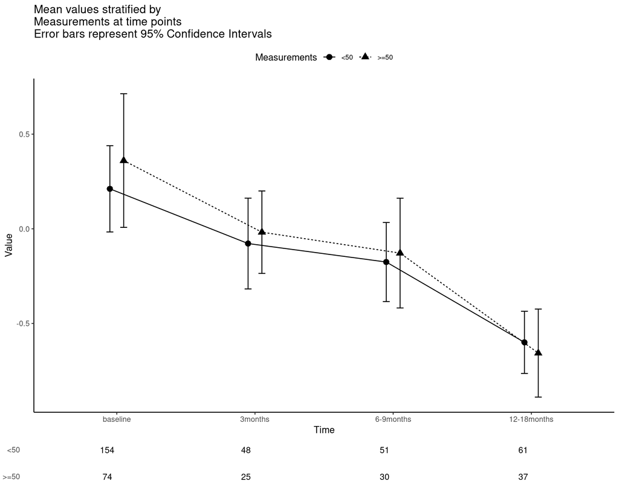

Figure : Measurements overtime (C-reactive protein with log-transformation)

```r
#adding a table of count for each time point under the plot
#raw table for counts
dat.tbl.plot1.raw <-
  dat.tidy %>%
    select(proj_id, crp_at_diagnosis, crp_at_three_months, crp_at_sixtonine, crp_at_twelvetoeighteen,
           calprotectin_dx, calprotectin_three, calprotectin_six_to_nine, calprotectin_12_18,
           mayoscore_before_dx, mayoscore_3months, mayoscore_6to9months, mayoscore_12_18months, age_group) %>%

    pivot_longer(cols = crp_at_diagnosis:mayoscore_12_18months, names_to = "names", values_to = "value") %>%
    mutate(
      variable = case_when(
        str_detect(names, "crp") ~"C-reactive protein",
        str_detect(names, "calprotectin") ~ "Fecal calprotectin",
        str_detect(names, "mayoscore") ~ "Mayo score",
        TRUE ~ NA_character_
      ),
      time = case_when(
        str_detect(names, "dx|diagnosis") ~"baseline",
        str_detect(names, "three|3months") ~ "3months",
        str_detect(names, "six|6to9months") ~ "6-9months",
        str_detect(names, "12|twelve") ~ "12-18months",
        TRUE ~ NA_character_
      ) %>% as_factor(),
      time = fct_relevel(time, c("baseline", "3months", "6-9months", "12-18months")) ) %>%
   mutate(
      value = case_when(
        variable %in% c("C-reactive protein", "Fecal calprotectin") ~ log(value),
        TRUE ~ value
      )
    ) %>%
    group_by(variable, time, age_group) %>%
  dplyr::summarise(count = sum(!is.na(value)) ) %>%
  ungroup(.)

#clean table for plot 1
dat.tbl.plot1 <-
  dat.tbl.plot1.raw %>% filter(variable == "C-reactive protein") %>%
  ggplot( aes(x = time, y = factor(age_group),  label = count)) +
  geom_text(size = 3.5) +
  theme_bw() + scale_y_discrete(limits = c( ">=50","<50")) +
  scale_x_discrete(limits = c("baseline", "3months", "6-9months", "12-18months")) +
  theme(panel.grid.major = element_blank(), #legend.position = "none",
        panel.border = element_blank(), axis.text.x = element_blank(),
        axis.ticks = element_blank()) +
  theme(plot.margin = unit(c(-0.5, 1, 0, 0.2), "lines")) +
  xlab(NULL) + ylab(NULL)

#customize grid to the page
#plot on top, table at the bottom, stacked together
library(grid)
Layout <- grid.layout(nrow = 2, ncol = 1, heights = unit(c(2, 0.25), c("null", "null")))

#grid.show.layout(Layout)
 vplayout <- function(...) {
  grid.newpage()
  pushViewport(viewport(layout = Layout))
 }
 subplot <- function(x, y) viewport(layout.pos.row = x,
                                    layout.pos.col = y)

#define function to stack the plot and the table
  mmplot <- function(a, b) {
   vplayout()
   print(a, vp = subplot(1, 1))
   print(b, vp = subplot(2, 1))
 }

 mmplot(plot1, dat.tbl.plot1)
```